```python
import IPython.display as ipd
```

← Back to Index

# Sheet Music Representations

Music can be represented in many different ways. The printed, visual form of a musical work is called a **score** or **sheet music**. For example, here is a sheet music excerpt from Mozart Piano Sonata No. 11 K. 331:

```python
ipd.SVG("https://upload.wikimedia.org/wikipedia/commons/2/27/MozartExcerptK331.svg")
```

[figure not shown]

```python
ipd.YouTubeVideo('dP9KWQ8hAYk')
```

[video not shown]

Sheet music consists of **notes**. A note has several properties including pitch, timbre, loudness, and duration.

**Pitch** (Wikipedia) is a perceptual property that indicates how "high" or "low" a note sounds. Pitch is closely related to the fundamental frequency sounded by the note, although fundamental frequency is a physical property of the sound wave.

An **octave** ([Wikipedia](https://en.wikipedia.org/wiki/Octave)) is an interval between two notes where the higher note is twice the fundamental frequency of the lower note. For example, an A at 440 Hz and an A at 880 Hz are separated by one octave. Here are two Cs separated by one octave:

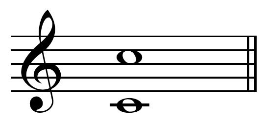

```python
ipd.Image("https://upload.wikimedia.org/wikipedia/commons/a/a5/Perfect_octave_on_C.png")
```

A **pitch class** ([Wikipedia](https://en.wikipedia.org/wiki/Pitch_class)) is the set of all notes that are an integer number of octaves apart. For example, the set of all Cs, {..., C1, C2, ...} is one pitch class, and the set of all Ds, {..., D1, D2, ...} is another pitch class. Here is the pitch class for C:

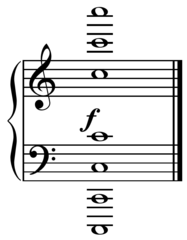

```python
ipd.Image("https://upload.wikimedia.org/wikipedia/commons/thumb/9/98/Pitch_class_on_C.png/187px-Pitch_class_on_C.png")
```

**Equal temperament** ([Wikipedia](https://en.wikipedia.org/wiki/Equal_temperament)) refers to the standard practice of dividing the octave into 12 uniform scale steps.

The difference between two subsequent scale steps is called a **semitone** ([Wikipedia](https://en.wikipedia.org/wiki/Semitone)), the smallest possible interval in the 12-tone equal tempered scale. Musicians may know this as a "half step."

The **key signature** ([Wikipedia](https://en.wikipedia.org/wiki/Key_signature)) follows the clef on a staff and indicates the key of the piece by the sharps or flats which are present throughout the piece. In the Mozart sonata excerpt above, the key signature is A major.

The **time signature** ([Wikipedia](https://en.wikipedia.org/wiki/Time_signature)) follows the key signature on the staff and indicates the rhythmic structure, or meter, of the piece. In the Mozart sonata excerpt above, the time signature is 6/8, i.e. six eighth notes in one measure.

**Tempo** ([Wikipedia](https://en.wikipedia.org/wiki/Tempo)) denotes how slow or fast a piece is played as measured by beats per minute (BPM). In the Mozart sonata excerpt above, the tempo marking is "Andante grazioso".

← Back to Index